# Exploring the BRFSS data

## Setup

### Load packages

```r
library(ggplot2)
library(dplyr)
```

### Load data

```r
load("brfss2013.RData")
```

## Part 1: Data

**Introduction:**

The Behavioral Risk Factor Surveillance System (BRFSS) is the nation’s premier system of health-related telephone surveys that collect state data about U.S. residents regarding their health-related risk behaviors, chronic health conditions, and use of preventive services. Established in 1984 with 15 states, BRFSS now collects data in all 50 states as well as the District of Columbia and three U.S. territories. BRFSS completes more than 400,000 adult interviews each year.

**Data Collection:**

To collect a large amount of data, states may opt to contract with a private company or university to conduct interviews or conduct interviews internally, but regardless of who conducts data collection, **it is done according to BRFSS protocols**. States generally follow a suggested BRFSS interviewing schedule and complete all calls for a given survey month within the same sample month. Whether data are collected in-house or by contracted organizations, states must develop and maintain procedures to **ensure respondents’ confidentiality**, assure and document the quality of the interviewing process, and supervise and monitor the interviewers. In order to conduct the BRFSS, states **obtain samples of telephone numbers** from CDC. States then review their sampling methodology with a state statistician and CDC to make sure data collection procedures are in place to follow the methodology. If any change in sampling methodology is considered, states consult with CDC before making changes. **The BRFSS uses two samples: one for landline telephone respondents and one for cellular telephone respondents.** Since landline telephones are often shared among persons living within a residence, household sampling is used in the landline sample. Household sampling requires interviewers to collect information on the number of adults living within a residence and then select randomly from all eligible adults. Cellular telephone respondents are weighted as single adult households.

**Summary:**

Since random sampling was drawn in both data collection methods, the data for the sample is generalizable to the adult population of the participating states.

However, it won’t be possible to make causal inferences from the data because this is an observational study.

## Part 2: Research questions

**Research quesion 1:**

Is there an association between the number of days with depressive symptoms and sleep hours? This question is significant since if we can discover the association between the number of days with depressive symptoms and sleep hours, we can suggest people who have depression problem to improve sleep quality first. On the other hand, we can suggest people who cannot sleep well do something relaxing or something fun making themselves happy.

**Research quesion 2:**

Is there an association between income level and alcoholic beverage drinking frequency? This question is interesing. There are plenty kinds of alcoholic beverage. Some of them are cheap, while some of them are expensive. Since people who are not very rich can still buy cheap alcoholic beverage, does the income level associate with the drinking frequency?

**Research quesion 3:**

Is there an association between exercise frequency and health condition, or is there an association between green vegetables consumption and health condition? Which one has larger association with health condition? This question is significant since if we can discover the association between health condition and other variables, we can suggest people do more exercise or consume more green vegetables in order to get healthier.

## Part 3: Exploratory data analysis

**Research quesion 1:**

Is there an association between the number of days with depressive symptoms and sleep hours?

- Plot the number of days with depressive symptoms versus average sleep hours

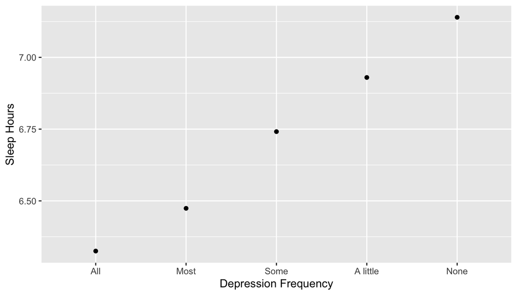

```r
brfss2013 %>%
  select(sleptim1, misdeprd) %>%
  filter(!is.na(sleptim1), !is.na(misdeprd)) %>%
  group_by(misdeprd) %>%
  summarise(m = mean(sleptim1)) %>%
  ggplot(aes(x = misdeprd, y = m)) + geom_point() + xlab("Depression Frequency") + ylab("Sleep Hours")
```

- Print summary of the number of days with depressive symptoms versus average sleep hours

```r
brfss2013 %>%
  select(sleptim1, misdeprd) %>%
  filter(!is.na(sleptim1), !is.na(misdeprd)) %>%
  group_by(misdeprd) %>%
  summarise(m = mean(sleptim1))
```

```
## # A tibble: 5 x 2
##   misdeprd     m
##   <fct>    <dbl>
## 1 All       6.33
## 2 Most      6.47
## 3 Some      6.74
## 4 A little  6.93
## 5 None      7.14
```

Based on the plot and summary, we can conclude there is an association between the number of days with depressive symptoms and sleep hours. That is, the respondents who have fewer depression problems sleep more on averge.

**Research quesion 2:**

Is there an association between income level and alcoholic beverage drinking frequency?

- Plot income level versus average alcoholic beverage drinking frequency
  - mutate new variable since some lables of `alcdays` represents different units. ex: monthly, weekly.

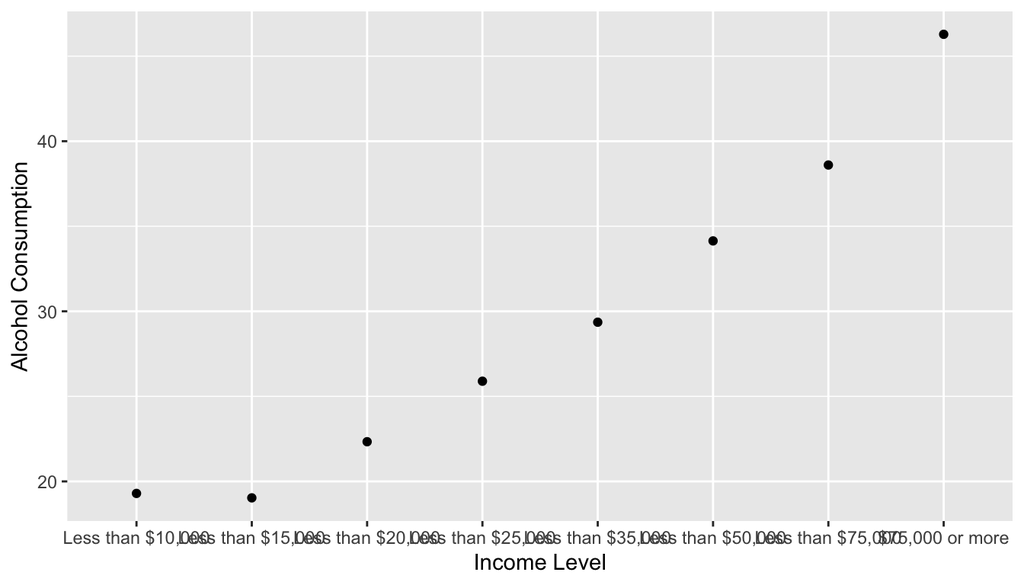

```r
df <- brfss2013 %>%
  mutate(alcday5_new = ifelse(alcday5>=201 & alcday5<=299, alcday5/4, alcday5),)
df %>%
  select(income2, alcday5_new) %>%
  filter(!is.na(alcday5_new), !is.na(income2)) %>%
  group_by(income2) %>%
  summarise(m = mean(alcday5_new)) %>%
  ggplot(aes(x = income2, y = m)) + geom_point() + xlab("Income Level") + ylab("Alcohol Consumption")
```

- Since the average alcohol consumption are very similar for the first two income levels (`Less than $10,000` and `Less than $15,000`), I view these two levels as the same level. Therefore, the plot will be like…

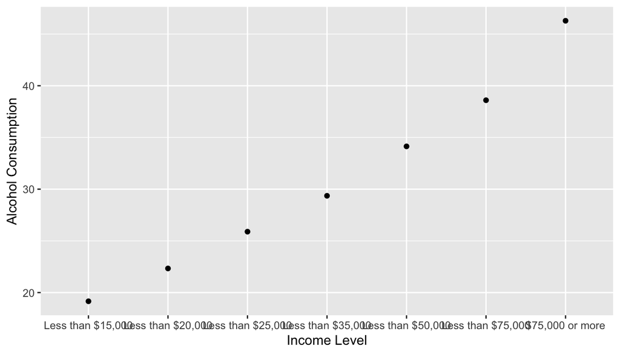

```r
df <- brfss2013 %>%
  mutate(income2_new = ifelse(as.character(income2)=="Less than $10,000", as.character("Less than $15,000"), as.character(income2)),) %>%
  mutate(alcday5_new = ifelse(alcday5>=201 & alcday5<=299, alcday5/4, alcday5),)
df$income2_new <- factor(df$income2_new, levels = c("Less than $15,000", "Less than $20,000", "Less than $25,000", "Less than $35,000", "Less than $50,000", "Less than $75,000", "$75,000 or more"))
df %>%
  select(income2_new, alcday5_new) %>%
  filter(!is.na(alcday5_new), !is.na(income2_new)) %>%
  group_by(income2_new) %>%
  summarise(m = mean(alcday5_new)) %>%
  ggplot(aes(x = income2_new, y = m)) + geom_point() + xlab("Income Level") + ylab("Alcohol Consumption")
```

- Print summary of income level versus average alcoholic beverage drinking frequency

```r
df %>%
  select(income2_new, alcday5_new) %>%
  filter(!is.na(alcday5_new), !is.na(income2_new)) %>%
  group_by(income2_new) %>%
  summarise(m = mean(alcday5_new))
```

```
## # A tibble: 7 x 2
##   income2_new           m
##   <fct>             <dbl>
## 1 Less than $15,000  19.2
## 2 Less than $20,000  22.3
## 3 Less than $25,000  25.9
## 4 Less than $35,000  29.4
## 5 Less than $50,000  34.1
## 6 Less than $75,000  38.6
## 7 $75,000 or more    46.3
```

Based on the plot and summary, we can conclude there is an association between income level and alcoholic beverage drinking frequency. That is, the respondents who are richer drink more oftern on averge.

**Research quesion 3:**

Is there an association between exercise frequency and health condition, or is there an association between green vegetables consumption and health condition? Which one has larger association with health condition?

- Plot health condition versus average exercise frequency
  - mutate new variable since some lables of `exeroft1` represents different units. ex: monthly, weekly.

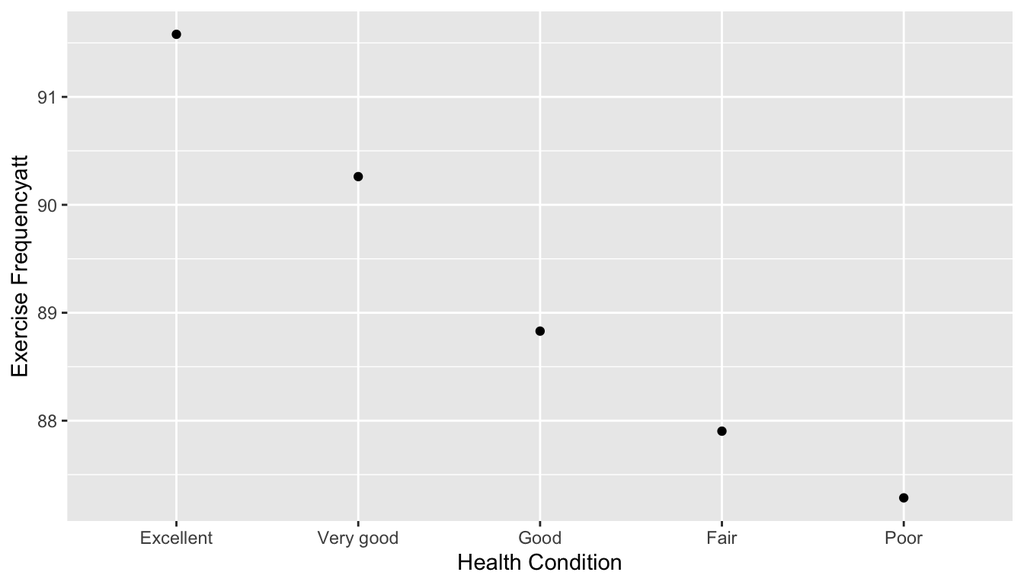

```r
df <- brfss2013 %>%
  mutate(exeroft1_new = ifelse(exeroft1>200, exeroft1/4, exeroft1))
df %>%
  select(genhlth, exeroft1_new) %>%
  filter(!is.na(genhlth), !is.na(exeroft1_new)) %>%
  group_by(genhlth) %>%
  summarise(m = mean(exeroft1_new)) %>%
  ggplot(aes(x = genhlth, y = m)) + geom_point() + xlab("Health Condition") + ylab("Exercise Frequencyatt")
```

- Print summary of health condition versus average exercise frequency

```r
df <- brfss2013 %>%
  mutate(exeroft1_new = ifelse(exeroft1>200, exeroft1/4, exeroft1))
df %>%
  select(genhlth, exeroft1_new) %>%
  filter(!is.na(genhlth), !is.na(exeroft1_new)) %>%
  group_by(genhlth) %>%
  summarise(m = mean(exeroft1_new))
```

```
## # A tibble: 5 x 2
##   genhlth       m
##   <fct>     <dbl>
## 1 Excellent  91.6
## 2 Very good  90.3
## 3 Good       88.8
## 4 Fair       87.9
## 5 Poor       87.3
```

Based on the plot and summary, we can conclude an association between exercise frequency and health condition. That is, the respondents who exercise more have better health condition

- Plot health condition versus average green vegetables consumption
  - mutate new variable since some lables of `fvgreen` represents different units. ex: monthly, weekly.

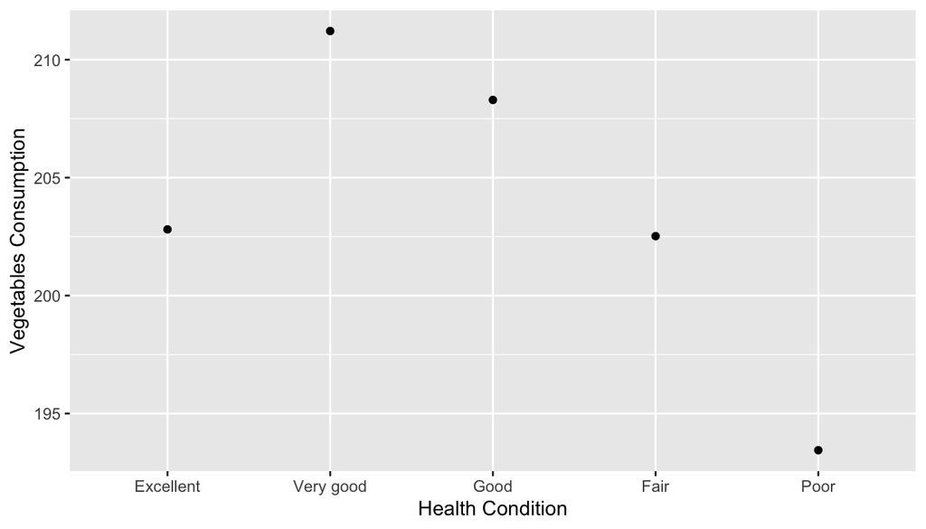

```r
df <- brfss2013 %>%
  mutate(fvgreen_new = ifelse(fvgreen>=201 & fvgreen<=299, fvgreen/7, fvgreen),) %>%
  mutate(fvgreen_new = ifelse(fvgreen>=301 & fvgreen<=399, fvgreen/30, fvgreen),) %>%
  mutate(fvgreen_new = ifelse(fvgreen==300, 0, fvgreen),)
df %>%
  select(genhlth, fvgreen_new) %>%
  filter(!is.na(genhlth), !is.na(fvgreen_new)) %>%
  group_by(genhlth) %>%
  summarise(m = mean(fvgreen_new)) %>%
  ggplot(aes(x = genhlth, y = m)) + geom_point() + xlab("Health Condition") + ylab("Vegetables Consumption")
```

- Print summary of health condition versus average green vegetables consumption

```r
df <- brfss2013 %>%
  mutate(fvgreen_new = ifelse(fvgreen>=201 & fvgreen<=299, fvgreen/7, fvgreen),) %>%
  mutate(fvgreen_new = ifelse(fvgreen>=301 & fvgreen<=399, fvgreen/30, fvgreen),) %>%
  mutate(fvgreen_new = ifelse(fvgreen==300, 0, fvgreen),)
df %>%
  select(genhlth, fvgreen_new) %>%
  filter(!is.na(genhlth), !is.na(fvgreen_new)) %>%
  group_by(genhlth) %>%
  summarise(m = mean(fvgreen_new))
```

```
## # A tibble: 5 x 2
##   genhlth       m
##   <fct>     <dbl>
## 1 Excellent  203.
## 2 Very good  211.
## 3 Good       208.
## 4 Fair       203.
## 5 Poor       193.
```

Based on the plot and summary, we can conclude an association between green vegetables consumption and health condition. However, the respondents who have `Excellent` health condition do not eat more green vegetables comparing to the respondents in other health condition. Therefore, the association between them is less than the association between exercise frequency and health condition. We would suggest people to exercise more in order to get heathier, but not ensure eat more and more green vegetables can help people to get much more heathier.